- Author: YJ Choi
- Date: 2019-04-09

This is an R Markdown document to assign UN’s regional classification to DHS countries (or any group of countries). In multi-country studies, regional classification is often an important variable. Different classification methods are used per various purposes, but a widely used standard classification is from UN Statistics Division’s [“standard country or area codes for statistical use (**M49 standard**)”](https://unstats.un.org/unsd/methodology/m49/). The M49 standard classification is used as reference in this markdown. The markdown file is available at [GitHub](https://github.com/yoonjoung/AssignRegionalClassification).

There are three sections in this document: 1. getting DHS country list, 2. getting UNSD’s list, and 3. merging the two.

## 1. DHS country list

See DHS website for countries that have conducted DHS surveys: (https://www.dhsprogram.com/Where-We-Work/).

Figure 1. Countries where DHS surveys have been conducted.

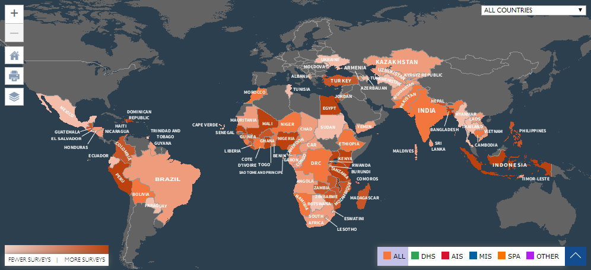

Access the list of countries from DHS API (http://api.dhsprogram.com/rest/dhs/countries?f=html). The API data also include regional classification variables (“region” and “sub-region”) that are used for the survey program purposes, which largely match with the UN classification.

```r
url<-("http://api.dhsprogram.com/rest/dhs/countries?f=json")

suppressPackageStartupMessages(library(jsonlite)) # for fromJSON
suppressPackageStartupMessages(library(data.table)) # for data.table
suppressPackageStartupMessages(library(dplyr))

# read DHS API country list
jsondata<-fromJSON(url)
# create data frame with countries & tidy
ctry_DHS<-data.table(jsondata$Data)
ctry_DHS<-ctry_DHS %>%
    rename (country =   CountryName) %>%
    rename (DHSregion1  =   RegionName) %>%
    rename (DHSregion2  =   SubregionName) %>%
    select (country, DHSregion1, DHSregion2)
```

## 2. UNSD country list

```r
url <- "https://unstats.un.org/unsd/methodology/m49/"

suppressPackageStartupMessages(library(XML)) # for HTMLparse
suppressPackageStartupMessages(library(RCurl)) # for readHTMLTable
suppressPackageStartupMessages(library(dplyr))
suppressPackageStartupMessages(library(Hmisc))
# download html page
html <- httr::POST(url = url, body = "")
# read the page
doc <- htmlParse(html)
# create data frame with countries & tidy
dtaraw <- readHTMLTable(doc)[[7]]
ctry_UNSD<-dtaraw %>%
    rename (country =   "Country or Area") %>%
    rename (M49 =   "M49 code") %>%
    rename (ISOalpha3   =   "ISO-alpha3 code") %>%
    select(country, M49, ISOalpha3)
```

Because the web table presents the region and country names in different row (see Figure 2), assign the lowest-level classification to individual countries. From there, higher level aggregation/grouping can be made as needed. Finally, replace county names as needed to merge with DHS country names.

Figure 2. Geographic regions table on the UNSD website (snapstop)

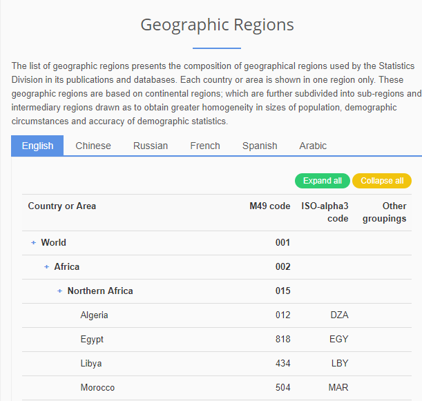

```r
# Assign sub-region names
head(ctry_UNSD, 20)
str(ctry_UNSD)
ctry_UNSD$country<-as.character(ctry_UNSD$country)
ctry_UNSD<-ctry_UNSD %>%
    mutate(
    UNSDsubregion=country,
    UNSDsubregion=ifelse(ISOalpha3!="", "", UNSDsubregion)
    )
for (i in 1:nrow(ctry_UNSD)){
    if (ctry_UNSD[i,4]==""){
    ctry_UNSD[i,4]=ctry_UNSD[i-1,4]
    }}
# Keep only country rows and replace country names as needed
ctry_UNSD<-ctry_UNSD %>%
    filter(ISOalpha3!="") %>%
    select(country, UNSDsubregion) %>%
    mutate(
    country = ifelse(country == "Bolivia (Plurinational State of)", "Bolivia", country) ,
    country = ifelse(country == "Cabo Verde", "Cape Verde", country) ,
    country = ifelse(country == "Democratic Republic of the Congo", "Congo Democratic Republic", country) ,
    country = ifelse(country == "Côte d'Ivoire", "Cote d'Ivoire", country) ,
    country = ifelse(country == "Kyrgyzstan", "Kyrgyz Republic", country) ,
    country = ifelse(country == "Republic of Moldova", "Moldova", country) ,
    country = ifelse(country == "United Republic of Tanzania", "Tanzania", country) ,
    country = ifelse(country == "Viet Nam", "Vietnam", country)
    )
label(ctry_UNSD$UNSDsubregion) <- "Sub-region, UNSD Methodology 49"
```

## 3. Merge DHS and UNSD M49 lists

Assess the two lists/data.

```r
dim(ctry_DHS)
dim(ctry_UNSD)
names(ctry_DHS)
names(ctry_UNSD)
obsDHS<-nrow(ctry_DHS)
obsUNSD<-nrow(ctry_UNSD)
```

[output not shown]

There are 91 “DHS countries”, and they need to be merged with the UNSD’s list of 248 countries.

```r
ctry<-left_join(ctry_DHS, ctry_UNSD, by = "country")
```

Make sure there the merged data have 91 countries, and no missing “UNSDsubregion”. **Especially**, check ‘Cote d’Ivoire’ (which often seems to have problems in merging when based on the country name), has UNSD subregion value. If not, assign it.

```r
nrow(ctry)
```

```
[1] 91
```

```r
addmargins(table(ctry$UNSDsubregion))
```

```
         Caribbean    Central America       Central Asia
                 3                  5                  5
    Eastern Africa     Eastern Europe          Melanesia
                13                  2                  1
     Middle Africa    Northern Africa          Polynesia
                 9                  4                  1
South-eastern Asia      South America    Southern Africa
                 8                  7                  5
     Southern Asia    Southern Europe     Western Africa
                 7                  1                 14
      Western Asia                Sum
                 5                 90
```

```r
# Check Cote d'Ivoire
test1<-filter(ctry, UNSDsubregion=="Western Africa")
table(test1$country)
```

```
       Benin Burkina Faso   Cape Verde       Gambia        Ghana
           1            1            1            1            1
      Guinea      Liberia         Mali   Mauritania        Niger
           1            1            1            1            1
     Nigeria      Senegal Sierra Leone         Togo
           1            1            1            1
```

```r
test2<-filter(ctry, DHSregion2=="Western Africa")
table(test2$country)
```

```
        Benin  Burkina Faso    Cape Verde Cote d'Ivoire        Gambia
            1             1             1             1             1
        Ghana        Guinea       Liberia          Mali    Mauritania
            1             1             1             1             1
        Niger       Nigeria       Senegal  Sierra Leone          Togo
            1             1             1             1             1
```

```r
# replace UNSDsubregion
ctry<-ctry %>%
    mutate(
    UNSDsubregion = ifelse(DHSregion2=="Western Africa", "Western Africa", UNSDsubregion)
    )
addmargins(table(ctry$UNSDsubregion))
```

```
         Caribbean    Central America       Central Asia
                 3                  5                  5
    Eastern Africa     Eastern Europe          Melanesia
                13                  2                  1
     Middle Africa    Northern Africa          Polynesia
                 9                  4                  1
South-eastern Asia      South America    Southern Africa
                 8                  7                  5
     Southern Asia    Southern Europe     Western Africa
                 7                  1                 15
      Western Asia                Sum
                 5                 91
```

Finally, a higher-level classification can be created depending on study purposes. In this example, a three-category grouping is done.

```r
ctry<-ctry %>%
    mutate(
    studyregion="",
    studyregion=ifelse(UNSDsubregion=="Middle Africa" |
                          UNSDsubregion=="Western Africa",
                     "Centera and Western Africa", studyregion),
    studyregion=ifelse(UNSDsubregion=="Eastern Africa" |
                          UNSDsubregion=="Southern Africa",
                     "Southern and Eastern Africa", studyregion),
    studyregion=ifelse(studyregion=="",
                     "Other Regions", studyregion)
    )
addmargins(table(ctry$UNSDsubregion, ctry$studyregion))
```

```
                     Centera and Western Africa Other Regions
  Caribbean                                   0             3
  Central America                             0             5
  Central Asia                                0             5
  Eastern Africa                              0             0
  Eastern Europe                              0             2
  Melanesia                                   0             1
  Middle Africa                               9             0
  Northern Africa                             0             4
  Polynesia                                   0             1
  South-eastern Asia                          0             8
  South America                               0             7
  Southern Africa                             0             0
  Southern Asia                               0             7
  Southern Europe                             0             1
  Western Africa                             15             0
  Western Asia                                0             5
  Sum                                        24            49

                     Southern and Eastern Africa Sum
  Caribbean                                    0   3
  Central America                              0   5
  Central Asia                                 0   5
  Eastern Africa                              13  13
  Eastern Europe                               0   2
  Melanesia                                    0   1
  Middle Africa                                0   9
  Northern Africa                              0   4
  Polynesia                                    0   1
  South-eastern Asia                           0   8
  South America                                0   7
  Southern Africa                              5   5
  Southern Asia                                0   7
  Southern Europe                              0   1
  Western Africa                               0  15
  Western Asia                                 0   5
  Sum                                         18  91
```

Acknowledgement: Trevor Croft at ICF International made helpful suggestions for the UNSD source and the web scraping code.